# From raw counts and a VCF to response eQTLs

This vignette goes from raw RNA-seq counts and a joint-called VCF to eQTL and response-eQTL calls, and ends with ancestry-specific eQTLs in admixed samples (section 8). The example data are simulated: 60 individuals, each sequenced in a control and a treated condition, with 300 genes and about 3,000 SNPs on chr22.

```r
library(suez)
library(edgeR)              # expression filtering and TMM normalization
library(VariantAnnotation)  # VCF reading
library(doMC)
registerDoMC(2)             # genes are tested in parallel
```

## 1. Input files

```r
ext = function(f) system.file("extdata", f, package = "suez")
counts  = read.delim(ext("counts.tsv.gz"), row.names = 1, check.names = FALSE)  # genes x samples
samples = read.delim(ext("samples.tsv"))       # sample_id, individual, condition
genes   = read.delim(ext("genes.tsv"))         # gene_id, chr, start, end (e.g. from a GTF)
head(samples, 3)
```

```
#>     sample_id individual condition
#> 1 IND001_ctrl     IND001   control
#> 2  IND001_trt     IND001   treated
#> 3 IND002_ctrl     IND002   control
```

```r
stopifnot(identical(colnames(counts), samples$sample_id))   # suez matches samples by position
```

## 2. Expression: filter and normalize

Keep genes with enough reads using `edgeR::filterByExpr`, then compute TMM-normalized log2 CPM.

```r
dge = DGEList(counts, group = samples$condition)
dge = dge[filterByExpr(dge), , keep.lib.sizes = FALSE]
dge = normLibSizes(dge)                          # TMM (calcNormFactors in edgeR < 4)
logcpm = cpm(dge, log = TRUE)
dim(logcpm)
```

```
#> [1] 240 120
```

## 3. Genotypes: read the VCF, filter, convert to dosages

Keep biallelic SNPs with a call rate of at least 95% and a minor allele frequency of at least 5%. Missing calls can stay `NA`: suez sets each to the SNP’s mean count over its calls (mean dosage).

```r
vcf = readVcf(ext("genotypes.vcf.gz"))
vcf = vcf[isSNV(vcf)]                            # biallelic SNPs
gt = geno(vcf)$GT
dosage = matrix(c("0/0" = 0, "0|0" = 0, "0/1" = 1, "0|1" = 1, "1|0" = 1, "1/1" = 2, "1|1" = 2)[gt],
                nrow(gt), dimnames = dimnames(gt))
call_rate = rowMeans(!is.na(dosage))
af = rowMeans(dosage, na.rm = TRUE) / 2
dosage = dosage[call_rate >= 0.95 & pmin(af, 1 - af) >= 0.05, ]
dim(dosage)
```

```
#> [1] 2479   60
```

```r
snploc = data.frame(snpid = rownames(dosage),
                    chr = as.character(seqnames(rowRanges(vcf)[rownames(dosage)])),
                    pos = start(rowRanges(vcf)[rownames(dosage)]))
geneloc = data.frame(geneid = genes$gene_id, chr = genes$chr, left = genes$start, right = genes$end)
```

## 4. Step 1: learn the sample covariance

`learn_covariance` models hidden confounders (latent factors), repeated samples of the same individual and, optionally, relatedness. Here the genetic relationship matrix (GRM) comes from the same SNPs; in a real study, build it from genome-wide, LD-pruned SNPs (e.g. with plink).

```r
Z = scale(t(dosage)); Z[is.na(Z)] = 0            # individuals x SNPs, standardized
grm = tcrossprod(Z) / ncol(Z)
```

```r
anno = data.frame(individual = samples$individual, condition = samples$condition)
qq = t(apply(logcpm, 1, function(x) qnorm((rank(x) - 0.5) / length(x))))   # per-gene normal scores
set.seed(1)                                      # rstan draws its seed from R's RNG
step1 = learn_covariance(qq, anno, kinship_matrix = grm, P = 10)
```

```r
round(step1$optimized_fit$par$s, 3)              # noise, same-individual and kinship variances
```

```
#> isotropic_noise        same_ind  kinship_matrix
#>           0.286           0.011           0.010
```

## 5. Step 2: map eQTLs and response eQTLs

Every SNP within 100 kb of a gene is tested for a genotype effect (`p_geno`) and a genotype x condition effect (`p_interact`).

```r
set.seed(1)
res = map_interaction_qtl(logcpm, dosage, geneloc, snploc, anno,
                          sample_kernel = step1$cov_suez, cisdist = 1e5)
```

```
#> Checkpoint dir:
#> Performing initial eigendecomposition...
```

```r
nrow(res)
```

```
#> [1] 13801
```

## 6. Multiple testing

Each gene has several correlated SNPs. A simple approach: Bonferroni within each gene (minimum p-value times the number of SNPs), then Benjamini-Hochberg across genes.

```r
gene_level = function(res, p) {
  top = do.call(rbind, lapply(split(res, res$gene), function(d) {
    i = which.min(d[[p]])
    data.frame(gene = d$gene[i], snp = d$cis_snp[i], p = d[[p]][i], p_gene = min(1, d[[p]][i] * nrow(d)))
  }))
  top$fdr = p.adjust(top$p_gene, "BH")
  top[order(top$p), ]
}
eqtl  = gene_level(res, "p_geno")
reqtl = gene_level(res, "p_interact")
c(eGenes = sum(eqtl$fdr < 0.05), response_eGenes = sum(reqtl$fdr < 0.05))
```

```
#>          eGenes response_eGenes
#>              37              13
```

```r
head(reqtl, 5)
```

```
#>                            gene       snp            p       p_gene
#> ENSG00000000121 ENSG00000000121 rs1001195 2.800132e-18 1.484070e-16
#> ENSG00000000151 ENSG00000000151 rs1001491 4.223989e-16 2.407674e-14
#> ENSG00000000021 ENSG00000000021 rs1000188 3.794388e-15 2.276633e-13
#> ENSG00000000084 ENSG00000000084 rs1000824 1.057325e-14 6.343947e-13
#> ENSG00000000291 ENSG00000000291 rs1002881 1.284692e-13 7.965092e-12
#>                          fdr
#> ENSG00000000121 3.561767e-14
#> ENSG00000000151 2.889208e-12
#> ENSG00000000021 1.821306e-11
#> ENSG00000000084 3.806368e-11
#> ENSG00000000291 3.823244e-10
```

Before trusting borderline calls, check that the p-values are calibrated. Most genes have no response eQTL, so the genomic inflation factor of `p_interact` over all tests should be close to 1:

```r
lambda = function(p) median(qchisq(p, 1, lower.tail = FALSE), na.rm = TRUE) / qchisq(0.5, 1)
c(geno = lambda(res$p_geno), interact = lambda(res$p_interact))
```

```
#>     geno interact
#> 1.008251 1.086487
```

A QQ plot shows the same thing across the whole distribution: points on the diagonal are null tests, and true effects rise above it at the top right.

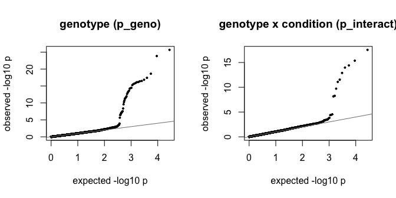

```r
qq = function(p, main) {
  p = sort(p[!is.na(p)]); e = -log10(ppoints(length(p)))
  plot(e, -log10(p), pch = 19, cex = 0.4, xlab = "expected -log10 p", ylab = "observed -log10 p", main = main)
  abline(0, 1, col = "grey50")
}
par(mfrow = c(1, 2))
qq(res$p_geno, "genotype (p_geno)")
qq(res$p_interact, "genotype x condition (p_interact)")
```

Because the data are simulated, we can compare the calls with the planted effects:

```r
truth = read.delim(ext("truth.tsv"))
hits = reqtl$gene[reqtl$fdr < 0.05]
table(planted = truth$type[match(hits, truth$gene_id)], useNA = "ifany")
```

```
#> planted
#> response eQTL          <NA>
#>            10             3
```

All planted response eQTLs are found. The `NA` calls are genes without a planted effect: a few more than a 5% FDR implies, which matches the mild inflation of `p_interact` above. Count noise makes the expression variance differ between conditions, and genotype x condition tests are sensitive to that. On real data, treat calls near the FDR threshold with care when the inflation factor is above 1.

## 7. Plot a response eQTL

All cis-SNPs of the top response gene, with the gene body in grey: the interaction signal peaks at one SNP.

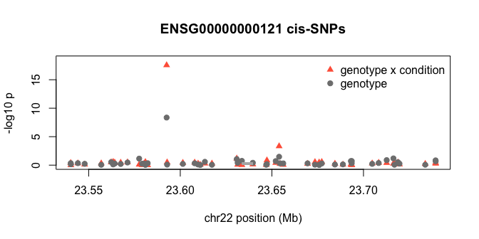

```r
top = reqtl[1, ]
d = res[res$gene == top$gene, ]
x = snploc$pos[match(d$cis_snp, snploc$snpid)] / 1e6
y = -log10(cbind(d$p_geno, d$p_interact))
plot(x, y[, 2], pch = 17, col = "tomato", ylim = c(0, max(y) * 1.05), xlab = "chr22 position (Mb)",
     ylab = "-log10 p", main = paste(top$gene, "cis-SNPs"))
points(x, y[, 1], pch = 19, col = "grey50")
gene_body = unlist(geneloc[geneloc$geneid == top$gene, c("left", "right")]) / 1e6
rect(gene_body[1], 0, gene_body[2], max(y) * 0.03, col = "grey70", border = NA)
legend("topright", c("genotype x condition", "genotype"), pch = c(17, 19), col = c("tomato", "grey50"), bty = "n")
```

Expression at the top SNP, by genotype and condition:

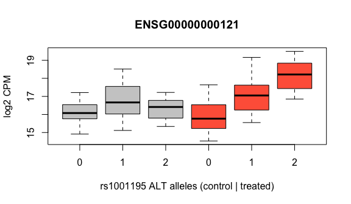

```r
top = reqtl[1, ]
g = dosage[top$snp, samples$individual]
boxplot(logcpm[top$gene, ] ~ g + samples$condition, col = rep(c("grey80", "tomato"), each = 3),
        names = rep(0:2, 2), xlab = paste(top$snp, "ALT alleles (control | treated)"),
        ylab = "log2 CPM", main = top$gene)
```

## 8. Admixed samples: local ancestry

In admixed individuals the same allele can have a different effect depending on the ancestry of the haplotype that carries it. suez can fit the models of Tractor: each genotype is split into the ALT alleles carried on each ancestry’s haplotypes, with local ancestry as a covariate. The input is Tractor’s per-ancestry files: phase the VCF, infer local ancestry (RFMix2 or FLARE), and run Tractor’s `extract_tracts.py`. The example cohort is simulated: 150 two-way admixed individuals (AFR/EUR, about 75% AFR) in two conditions, 80 genes, with AFR-only, EUR-only and shared eQTLs and AFR-only response eQTLs.

```r
adm = function(f) ext(file.path("admixed", f))
la = read_tractor(sub("\\.anc0\\.dosage\\.txt\\.gz$", "", adm("cohort.anc0.dosage.txt.gz")),
                  ancestry_names = c("AFR", "EUR"))     # anc0, anc1 as in the local-ancestry calls
str(la, max.level = 1)
```

```
#> List of 3
#>  $ dosage  :List of 2
#>  $ hapcount:List of 2
#>  $ snploc  :'data.frame':    1200 obs. of  3 variables:
```

```r
samples_a = read.delim(adm("samples.tsv"))
genes_a = read.delim(adm("genes.tsv"))
counts_a = read.delim(adm("counts.tsv.gz"), row.names = 1, check.names = FALSE)
dge_a = DGEList(counts_a, group = samples_a$condition)
logcpm_a = cpm(normLibSizes(dge_a[filterByExpr(dge_a), , keep.lib.sizes = FALSE]), log = TRUE)
```

Keep the GRM in step 1: it accounts for relatedness and does not absorb ancestry-specific effects. Global ancestry (here the mean AFR local ancestry; RFMix’s `.Q` file or genotype PCs also work) goes in as a fixed covariate.

```r
Z = scale(t(la$dosage$AFR + la$dosage$EUR))
grm_a = tcrossprod(Z) / ncol(Z)
global = colMeans(la$hapcount$AFR) / 2                   # AFR fraction per individual
anno_a = data.frame(individual = samples_a$individual, condition = samples_a$condition)
qq_a = t(apply(logcpm_a, 1, function(x) qnorm((rank(x) - 0.5) / length(x))))
set.seed(1)
step1_a = learn_covariance(qq_a, anno_a, kinship_matrix = grm_a, P = 5)
```

```r
geneloc_a = data.frame(geneid = genes_a$gene_id, chr = genes_a$chr, left = genes_a$start, right = genes_a$end)
set.seed(1)
res_a = map_interaction_qtl(logcpm_a, NULL, geneloc_a, la$snploc, anno_a,
                            sample_kernel = step1_a$cov_suez, cisdist = 1e5,
                            local_ancestry = la, covariates = cbind(AFR = global[anno_a$individual]))
```

```
#> Checkpoint dir:
#> Performing initial eigendecomposition...
```

Each SNP gets a joint eQTL test (`p_geno`), a test of whether the effects differ between ancestries (`p_het`), a response test (`p_interact`), and an effect per ancestry (`beta_AFR`, `beta_EUR`, `beta_interact_AFR`, …). At the planted SNPs:

```r
truth_a = read.delim(adm("truth.tsv"))
at = merge(truth_a, res_a, by.x = c("gene_id", "snp"), by.y = c("gene", "cis_snp"))
aggregate(cbind(beta_AFR, beta_EUR, beta_interact_AFR, beta_interact_EUR) ~ type, at,
          function(x) round(mean(x), 2))
```

```
#>                type beta_AFR beta_EUR beta_interact_AFR beta_interact_EUR
#> 1          AFR eQTL     0.84     0.02              0.03              0.00
#> 2 AFR response eQTL     0.55     0.01              1.09              0.04
#> 3          EUR eQTL    -0.01     1.20              0.00             -0.02
#> 4       shared eQTL     0.63     0.62             -0.04              0.10
```

```r
aggregate(cbind(eQTL = p_geno < 1e-3, differs = p_het < 0.05, response = p_interact < 1e-3) ~ type, at, mean)
```

```
#>                type eQTL differs response
#> 1          AFR eQTL    1       1        0
#> 2 AFR response eQTL    1       1        1
#> 3          EUR eQTL    1       1        0
#> 4       shared eQTL    1       0        0
```

The per-ancestry effects match the simulation (AFR only, EUR only, both, or an AFR-only response), and `p_het` separates the ancestry-specific eQTLs from the shared ones. The standard model on the pooled genotype, `map_interaction_qtl(logcpm_a, la$dosage$AFR + la$dosage$EUR, ...)`, finds 6 of the 8 EUR-only eQTLs at the same threshold, against 8 of 8 here: the EUR minority is diluted when ancestries are pooled.

The two ancestry effects at the lead SNP of every gene with an eQTL: AFR-only eQTLs lie on the x axis, EUR-only ones on the y axis and shared ones on the diagonal.

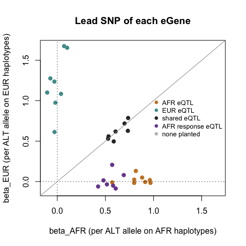

```r
lead = do.call(rbind, lapply(split(res_a, res_a$gene), function(d) d[which.min(d$p_geno), ]))
lead = lead[lead$p_geno < 1e-3, ]
type = truth_a$type[match(lead$gene, truth_a$gene_id)]
type[is.na(type)] = "none planted"
cols = c("AFR eQTL" = "#c9822b", "EUR eQTL" = "#4f9c9a", "shared eQTL" = "grey20",
         "AFR response eQTL" = "#7a4a9e", "none planted" = "grey75")
lim = range(c(lead$beta_AFR, lead$beta_EUR), na.rm = TRUE)
plot(lead$beta_AFR, lead$beta_EUR, pch = 19, col = cols[type], xlim = lim, ylim = lim,
     xlab = "beta_AFR (per ALT allele on AFR haplotypes)", ylab = "beta_EUR (per ALT allele on EUR haplotypes)",
     main = "Lead SNP of each eGene")
abline(h = 0, v = 0, lty = 3); abline(0, 1, col = "grey60")
legend("right", names(cols), pch = 19, col = cols, bty = "n", cex = 0.8)
```

An AFR-only response eQTL: expression rises with the ALT alleles carried on AFR haplotypes, in treated samples only. The raw EUR panel even slopes down in treated samples, because individuals with more EUR haplotypes carry fewer AFR ones; the model separates the two through the local-ancestry term, and the estimated EUR response (`beta_interact_EUR`) is close to 0.

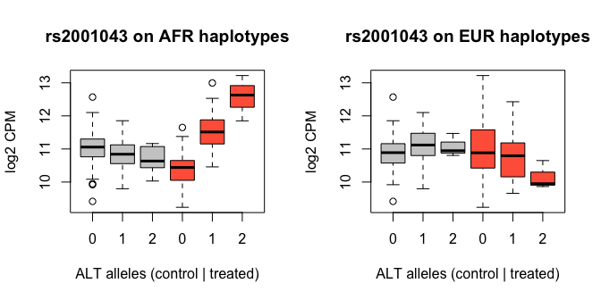

```r
r = truth_a[truth_a$type == "AFR response eQTL", ][1, ]
par(mfrow = c(1, 2))
for (a in c("AFR", "EUR")) {
  dose = factor(la$dosage[[a]][r$snp, samples_a$individual], levels = 0:2)
  boxplot(split(logcpm_a[r$gene_id, ], interaction(dose, samples_a$condition)),
          col = rep(c("grey80", "tomato"), each = 3), names = rep(0:2, 2), ylab = "log2 CPM",
          xlab = "ALT alleles (control | treated)", main = paste(r$snp, "on", a, "haplotypes"))
}
```

At a SNP that only tags the causal variant, LD that differs between ancestries can also make effects look different, so fine-map before interpreting `p_het` at non-lead SNPs.

## Notes

- `map_interaction_qtl` can also read genotypes straight from the VCF: `genotype = Rsamtools::TabixFile(ext("genotypes.vcf.gz"))`. The filters in section 3 are then not applied; use `maf_threshold` instead.
- Use `checkpoint_dir` on large runs so a crashed run can resume, and save `res` with `readr::write_tsv()`.
- See the README for the meaning of every output column and for calibrating `p_interact` with the bootstrap columns.